# Personal Loan Campaign - Michelle Lozano

### Visualizing the Decision Tree

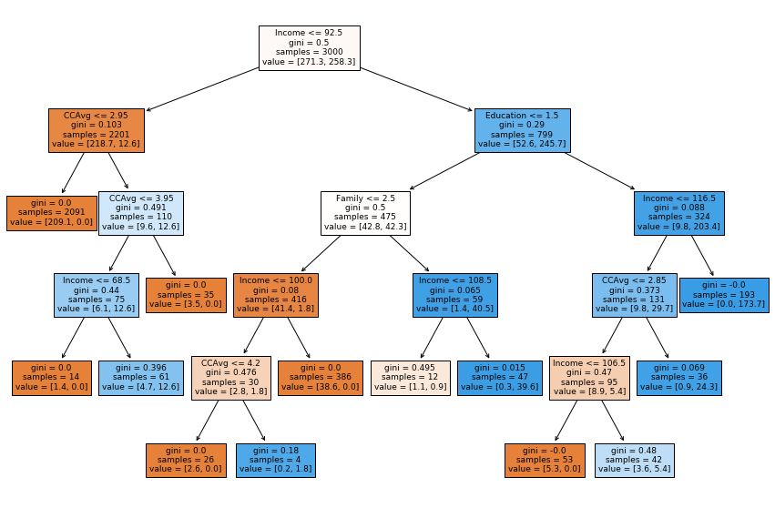

```python
plt.figure(figsize=(15, 10))

out = tree.plot_tree(
    best_model2,
    feature_names=feature_names,
    filled=True,
    fontsize=9,
    node_ids=False,
    class_names=None,
)
for o in out:
    arrow = o.arrow_patch
    if arrow is not None:
        arrow.set_edgecolor("black")
        arrow.set_linewidth(1)
plt.show()
```

```python
# Text report showing the rules of a decision tree -

print(tree.export_text(best_model2, feature_names=feature_names, show_weights=True))
```

```
|--- Income <= 92.50
|   |--- CCAvg <= 2.95
|   |   |--- weights: [209.10, 0.00] class: 0
|   |--- CCAvg >  2.95
|   |   |--- CCAvg <= 3.95
|   |   |   |--- Income <= 68.50
|   |   |   |   |--- weights: [1.40, 0.00] class: 0
|   |   |   |--- Income >  68.50
|   |   |   |   |--- weights: [4.70, 12.60] class: 1
|   |   |--- CCAvg >  3.95
|   |   |   |--- weights: [3.50, 0.00] class: 0
|--- Income >  92.50
|   |--- Education <= 1.50
|   |   |--- Family <= 2.50
|   |   |   |--- Income <= 100.00
|   |   |   |   |--- CCAvg <= 4.20
|   |   |   |   |   |--- weights: [2.60, 0.00] class: 0
|   |   |   |   |--- CCAvg >  4.20
|   |   |   |   |   |--- weights: [0.20, 1.80] class: 1
|   |   |   |--- Income >  100.00
|   |   |   |   |--- weights: [38.60, 0.00] class: 0
|   |   |--- Family >  2.50
|   |   |   |--- Income <= 108.50
|   |   |   |   |--- weights: [1.10, 0.90] class: 0
|   |   |   |--- Income >  108.50
|   |   |   |   |--- weights: [0.30, 39.60] class: 1
|   |--- Education >  1.50
|   |   |--- Income <= 116.50
|   |   |   |--- CCAvg <= 2.85
|   |   |   |   |--- Income <= 106.50
|   |   |   |   |   |--- weights: [5.30, 0.00] class: 0
|   |   |   |   |--- Income >  106.50
|   |   |   |   |   |--- weights: [3.60, 5.40] class: 1
|   |   |   |--- CCAvg >  2.85
|   |   |   |   |--- weights: [0.90, 24.30] class: 1
|   |   |--- Income >  116.50
|   |   |   |--- weights: [0.00, 173.70] class: 1
```

```python
# importance of features in the tree building ( The importance of a feature is computed as the
# (normalized) total reduction of the 'criterion' brought by that feature. It is also known as the Gini importance )

print(
    pd.DataFrame(
        best_model2.feature_importances_, columns=["Imp"], index=X_train.columns
    ).sort_values(by="Imp", ascending=False)
)
```

```
                         Imp
Income              0.657667
Family              0.145689
Education           0.101693
CCAvg               0.094951
Age                 0.000000
Securities_Account  0.000000
CD_Account          0.000000
Online              0.000000
CreditCard          0.000000
MortgageLoan        0.000000
```

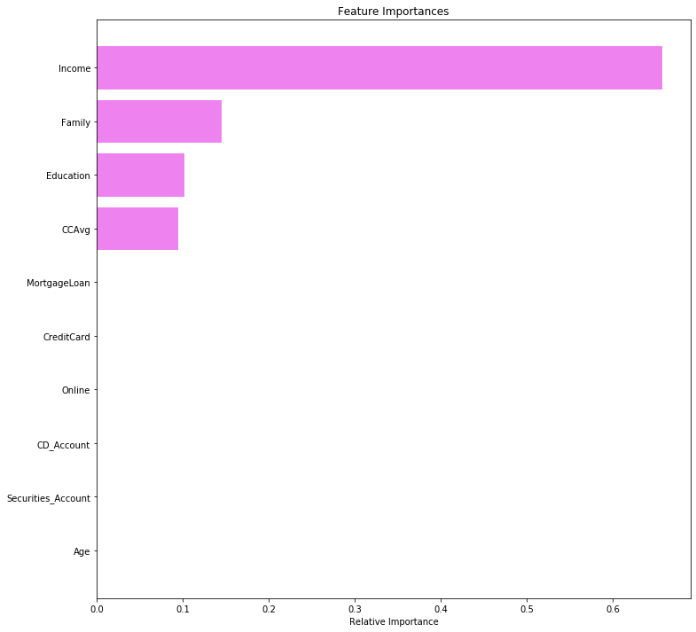

```python
importances = best_model2.feature_importances_
indices = np.argsort(importances)

plt.figure(figsize=(12, 12))
plt.title("Feature Importances")
plt.barh(range(len(indices)), importances[indices], color="violet", align="center")
plt.yticks(range(len(indices)), [feature_names[i] for i in indices])
plt.xlabel("Relative Importance")
plt.show()
```

### Comparing all the decision tree models

```python
# training performance comparison

models_train_comp_df = pd.DataFrame(
    [
        decision_tree_perf_train,
        decision_tree_tune_perf_train,
        decision_tree_postpruned1_perf_train,
        decision_tree_postpruned2_perf_train,
    ],
    columns=["Recall on training set"],
)

print("Training performance comparison:")
models_train_comp_df
```

```
Training performance comparison:
```

|  | Recall on training set |
| --- | --- |
| 0 | 1.000000 |
| 1 | 0.933798 |
| 2 | 0.993031 |
| 3 | 0.996516 |

```python
# testing performance comparison

models_test_comp_df = pd.DataFrame(
    [
        decision_tree_perf_test,
        decision_tree_tune_perf_test,
        decision_tree_postpruned1_perf_test,
        decision_tree_postpruned2_perf_test,
    ],
    columns=["Recall on testing set"],
)

print("Test performance comparison:")
models_test_comp_df
```

```
Test performance comparison:
```

|  | Recall on testing set |
| --- | --- |
| 0 | 0.854922 |
| 1 | 0.865285 |
| 2 | 0.979275 |
| 3 | 0.943005 |

### Conclusions

- First campaign respect "Personal Loan Acceptance " was analyzed using logistic regression and Decision Tree Classifier.
- The model built identifies the potential customers who have higher probability of purchasing perosnal loan. Therefore, maximizing recall will reduce the chances of offering a personal loan who is not interested.
- Considering logistic regresion with p=9.6% and Decision tree model with post-pruning recall results, Decision tree was chosen for customer segmentation. Train recall is 0.993031 and test recall is .979275.
- Imbalanced classes were analyzed in the Decision Tree with post-prunning and an easy interpretation was obtained.
- Income, size of family, eduaction level and Credit Card average spend are the most important variable in predicting the customers that will accept a personal loan.
- The importance of hyper-parameters and post-pruning was analyzed in order to reduce overfitting.

### Recommendations

[output not shown]